# Final Project

FP-7: Jeffrey Liang, Jingjing Chen, Xinyu Zhang

December 5th, 2024

# Report Introduction

As the Director of Policy and Plan Design at BlueStar Health, your role is pivotal in shaping insurance solutions that balance affordability, accessibility, and comprehensive coverage. BlueStar serves a diverse customer base, each with unique healthcare needs and challenges. In an evolving healthcare landscape marked by rising costs, varying utilization patterns, and the increasing importance of equitable access, understanding the complexities of healthcare delivery is critical for ensuring the effectiveness and competitiveness of BlueStar’s offerings.

One of the most pressing challenges faced by health insurers is fraudulent or anomalous activity within healthcare utilization and cost patterns. Globally, over seven billion dollars are spent on health services annually, with an estimated 10% to 25% of this expenditure lost to corruption (Jones & Jing, 2011). This staggering loss surpasses the projected annual cost of achieving universal health coverage by 2030 (World Bank, 2019), underscoring the immense financial burden fraud places on healthcare systems. For insurance providers like BlueStar, such fraud not only inflate premiums but also reduce the funds available for legitimate claims, undermine stakeholder trust, and create operational inefficiencies.

In addition, analyzing cost drivers is critical for ensuring the financial sustainability of insurance offerings. Predictive models play a vital role in this process by providing actionable insights at both the individual and aggregate levels. At the individual level, these models are used for risk classification and determining premiums and loadings tailored to each policyholder (Shi, Feng, & Ivantsova, 2015), ensuring equitable pricing while managing potential liabilities. At the aggregate level, predictive models quantify the risk of a portfolio or a block of business, aiding insurers in selecting the appropriate levels of risk capital and structuring treaty or facultative reinsurance arrangements (Shi, Feng, & Ivantsova, 2015). This dual application not only supports effective cost management but also ensures the company’s financial resilience in the face of diverse and complex risks. This comprehensive approach to managing costs enables BlueStar to maintain competitive premiums, enhance affordability, and foster member loyalty.

Designing customer-centric insurance solutions by optimizing deductible structures enables BlueStar to enhance affordability and accessibility for members while prioritizing their overall health outcomes. A thoughtfully calibrated deductible not only alleviates financial barriers to necessary care but also serves as a strategic tool to attract and retain members by aligning insurance plans with their preferences and health needs. This approach is particularly significant in managing chronic conditions such as diabetes, where leveraging primary healthcare—which primarily offers outpatient services—has been shown to play a crucial role in maximizing health outcomes (Van Loenen et al., 2016). By fostering easier access to preventative and primary care services, BlueStar can support better health management for its members, reinforcing loyalty and ensuring long-term sustainability in a competitive market.

This report leverages data-driven insights to address these critical questions, providing actionable recommendations to refine BlueStar’s policy offerings. By detecting fraud, understanding cost variations, and assessing patient behavior, BlueStar can align its plans more closely with customer needs, optimize resource allocation, and maintain its reputation as a leader in the health insurance industry. Through these efforts, BlueStar can continue to deliver on its mission of providing affordable, high-quality healthcare solutions to a diverse and growing customer base.

# Research Questions

## RQ1: Fraud Detection (Jeffrey Liang 100%)

### Introduction

As the Director of Policy and Plan Design at BlueStar Health, your commitment to providing affordable and comprehensive health insurance plans is essential to serving a diverse customer base across multiple states. To support this mission, our analysis focuses on identifying potential anomalies in healthcare utilization and costs that may impact the effectiveness and competitiveness of BlueStar Health’s offerings.

*RQ1: How can BlueStar Health detect potential fraud or anomalies in healthcare utilization and cost patterns across providers and organizations?*

To address this research question, we have structured our workflow into the following key components:

**1.1 Providers with Unusually High Utilization Rates**

Purpose: Identify healthcare providers whose utilization rates significantly deviate from the norm.

Importance: Unusually high utilization rates may indicate overbilling, unnecessary services, or fraudulent activities, which can inflate costs for both the insurer and policyholders. Detecting these providers is crucial for cost control and maintaining affordable premiums.

**1.2 Patients with Unusually High Healthcare Expenses or Coverage**

Purpose: Detect patients who have exceptionally high healthcare expenses or insurance coverage amounts.

Importance: Such anomalies may point to cases of insurance abuse, medical identity theft, or chronic conditions requiring intensive care. Understanding these patterns helps in risk assessment and tailoring plan benefits appropriately.

**1.3 Cross-Referencing Providers and High-Expense Patients**

Purpose: Link providers to high-expense patients to uncover potential correlations.

Importance: This step helps in identifying whether certain providers are associated with unusually high patient costs, which could indicate collaborative fraudulent activities or the need for provider education on cost-effective treatments.

**1.4 Providers with Unusually High Number of Encounters with High-Expense Patients**

Purpose: Identify providers who frequently interact with high-expense patients beyond expected levels.

Importance: Frequent encounters may suggest patterns of unnecessary follow-ups or procedures. Highlighting these providers allows for targeted audits and encourages adherence to best practices.

**By systematically analyzing these areas, we aim to equip BlueStar Health with actionable insights to:**

Optimize Cost-Sharing Structures: Reduce unnecessary expenses to keep premiums affordable.

Enhance Plan Offerings: Adjust benefits and coverage options based on identified risks and patient needs.

Stay Competitive: Improve operational efficiency and value proposition in the health insurance market.

This comprehensive approach ensures that BlueStar Health can make informed decisions to benefit both the company and its policyholders.

#### 1.1 Providers with Unusually High Utilization Rates

|  | providers_id | name | utilization |
| --- | --- | --- | --- |
| 1 | 6950d4cc-a2f1-3ef2-b56a-51e152b34262 | Mathew182 Cummings51 | 573 |
| 2 | 2dd0b828-6192-3ba9-93c4-dc58c549d15a | Danial835 Ratke343 | 526 |
| 3 | 854b4988-cafc-3824-af4e-cb530267a39c | Allan198 Moore224 | 441 |
| 4 | 8ae60740-70ad-3946-a776-2b103c3fa1f9 | Denisha680 Schmitt836 | 367 |
| 5 | 29c664f8-c535-35a3-9ba1-def5d627faaf | Elin732 Denesik803 | 313 |
| 6 | 851d22e8-3b0a-3dd8-a5f1-1c6edaf5b2cb | Rudolf736 Vandervort697 | 298 |
| 7 | 8dad88a1-94ef-340f-8e73-bf6b66b0b612 | Cristi782 Leannon79 | 297 |
| 8 | c2e0cf25-15d3-3ddd-9502-dc9c46cb04e3 | Marcus77 Schamberger479 | 273 |
| 9 | 1abf1c68-3c92-34a1-9514-24107fdf3896 | Teodoro374 Koss676 | 267 |

In this analysis, we examine the utilization rates of healthcare providers to identify those with unusually high values. Utilization refers to the number of healthcare services rendered by a provider, serving as an indicator of how frequently a provider is engaged in patient care within a given timeframe.

Using the z-score method, we identified providers whose utilization rates are more than three standard deviations above the mean. The providers listed in the table have utilization rates ranging from 267 to 573, which are significantly higher than the average.

**These unusually high utilization rates may indicate potential anomalies such as:**

Overutilization of Services: Providers might be offering more services than medically necessary.

Upcoding or Overbilling: There could be billing for more expensive services than those actually provided.

Fraudulent Activities: Intentional misrepresentation for financial gain.

**Identifying these providers is essential for BlueStar Health to:**

Investigate and audit the providers to ensure compliance with billing practices.

Implement measures to prevent unnecessary costs, thereby keeping insurance premiums affordable.

Enhance plan offerings by ensuring that policyholders receive appropriate and necessary care.

#### 1.2 Patients with Unusually High Healthcare Expenses or Coverage

|  | patients_id | name | healthcare_expenses | healthcare_coverage |
| --- | --- | --- | --- | --- |
| 1 | 59a7188a-2c62-2a19-e660-0dcfd7b7471f | Tanya49 Bednar518 | 3148039.96 | 675958.52 |
| 2 | 3fbdf6a3-b960-6845-247f-fa3c3831eb39 | Ethan766 Nikolaus26 | 2397565.36 | 100348.71 |
| 3 | 89d49cc7-e3e3-d9cb-80b2-8817782386d5 | Dulcie148 Wolff180 | 1955090.82 | 663746.39 |
| 4 | 77df4fc4-0afe-b9a7-3e7e-b047e912f03c | Marsha122 Bode78 | 1885113.66 | 126274.3 |
| 5 | 1a4d509d-f461-ed84-a9b5-4ec60221bc58 | Scott935 Schultz619 | 159223.24 | 5369267.38 |
| 6 | d70a6bbf-8ebd-77e0-2f04-d3369c9f0fcb | Silas208 Schaefer657 | 136737.26 | 3397318.91 |
| 7 | 19b01f9d-0277-0acd-9c05-74d4cb223703 | Alfonso758 Solorzano931 | 69425.61 | 5791877.79 |

Using the z-score method, we detect outliers in both healthcare_expenses and healthcare_coverage. Patients who are outliers in either category are compiled into patients_outliers.

The resulting table lists patients whose expenses or coverage significantly exceed the average. For instance, some patients have healthcare expenses surpassing $1 million, while others have coverage amounts in the multi-million-dollar range.

**Interpretation:**

Potential Anomalies: These extreme values may indicate possible fraud, billing errors, or data entry mistakes.

High-Cost Cases: Alternatively, they could represent patients with severe medical conditions requiring expensive treatments.

**Implications for BlueStar Health:**

Investigation Needed: It’s crucial to review these cases to verify the legitimacy of the expenses and coverage.

Cost Management: Identifying such outliers helps in controlling costs and ensuring the sustainability of insurance plans.

Policy Adjustment: Insights gained can inform adjustments in plan design and fraud prevention measures.

#### 1.3 Cross-Referencing Providers and Patients

|  | providers_id | name | high_expense_encounters |
| --- | --- | --- | --- |
| 1 | 6950d4cc-a2f1-3ef2-b56a-51e152b34262 | Mathew182 Cummings51 | 298 |
| 2 | 1abf1c68-3c92-34a1-9514-24107fdf3896 | Teodoro374 Koss676 | 247 |
| 3 | 8ae60740-70ad-3946-a776-2b103c3fa1f9 | Denisha680 Schmitt836 | 95 |
| 4 | 2dd0b828-6192-3ba9-93c4-dc58c549d15a | Danial835 Ratke343 | 79 |
| 5 | 851d22e8-3b0a-3dd8-a5f1-1c6edaf5b2cb | Rudolf736 Vandervort697 | 77 |
| 6 | 798917e8-f3cf-35da-b1ee-168c0cdbcbbd | Millie392 Eichmann909 | 61 |
| 7 | 854b4988-cafc-3824-af4e-cb530267a39c | Allan198 Moore224 | 56 |
| 8 | 23a914ca-b7f8-3559-8f58-47af7ac1d4e8 | Ilene33 Greenholt190 | 55 |
| 9 | d858d9dc-1ef8-3603-b45e-a94da579ea9c | Clement78 Gleason633 | 54 |
| 10 | 6ed8125a-e5dd-3393-9cd3-0f80ebe65ef1 | Patsy569 Olson653 | 41 |

[output cut: 18 more lines]

In this analysis, we aimed to identify providers with an unusually high number of encounters involving high-expense patients. We began by extracting the patient IDs of those identified as having unusually high healthcare expenses or coverage from the patients_outliers dataset. Using these IDs, we filtered the encounters dataset to select only the encounters that involved these high-expense patients. We then grouped the filtered encounters by providers_id and counted the number of such encounters per provider to quantify their interactions with high-expense patients. By merging this count with the providers dataset, we obtained detailed information about each provider and their respective number of high-expense encounters. Finally, we arranged the results in descending order to highlight the providers with the highest counts.

**Interpretation:**

The resulting table lists providers who have the most encounters with high-expense patients. For instance, Mathew182 Cummings51 had 298 encounters, and Teodoro374 Koss676 had 247 encounters with high-expense patients. These high numbers may indicate specialization in treating complex conditions, but they could also suggest potential overutilization or fraudulent activities, warranting further investigation by BlueStar Health.

#### Final Integrated Analysis: Identifying High-Risk Providers and Their Organizations

|  | providers_id | name | utilization | high_expense_encounters | organizations_id | organization_name |
| --- | --- | --- | --- | --- | --- | --- |
| 1 | 6950d4cc-a2f1-3ef2-b56a-51e152b34262 | Mathew182 Cummings51 | 573 | 298 | d05cf213-0e2e-3764-b00e-74c3f97b2fba | Gadsden CBOC |
| 2 | 2dd0b828-6192-3ba9-93c4-dc58c549d15a | Danial835 Ratke343 | 526 | 79 | a0fa18c3-08aa-3148-b00f-80307dfde24a | THE EAST ALABAMA HEALTH CARE AUTHORITY |
| 3 | 854b4988-cafc-3824-af4e-cb530267a39c | Allan198 Moore224 | 441 | 56 | 35cc9b18-6079-3810-b19b-8c7059e05c36 | BBH SBMC LLC |
| 4 | 8ae60740-70ad-3946-a776-2b103c3fa1f9 | Denisha680 Schmitt836 | 367 | 95 | 161b9ee7-a47e-304a-bcd7-f2e87a3e24b5 | Mobile Outpatient Clinic |
| 5 | 851d22e8-3b0a-3dd8-a5f1-1c6edaf5b2cb | Rudolf736 Vandervort697 | 298 | 77 | 14b4c57d-54cd-37bd-a53d-f6a5834c4dc3 | THE HEALTH CARE AUTHORITY OF THE CITY OF HUNTSVILLE |
| 6 | 1abf1c68-3c92-34a1-9514-24107fdf3896 | Teodoro374 Koss676 | 267 | 247 | 8d681261-7b22-3491-9d3e-9fc349e4933d | Selma Outpatient Clinic |

In this integrated analysis, we combined the findings from previous sections to identify providers who not only have unusually high utilization rates but also a high number of encounters with high-expense patients. By doing so, we aimed to pinpoint providers who may pose a higher risk of contributing to unnecessary costs due to potential overutilization or fraudulent activities.

**Key Findings:**

1. Overlap of High Utilization and High-Expense Encounters:

Six providers were identified who appear in both the high utilization outliers and have a significant number of encounters with high-expense patients. These providers have utilization rates ranging from 267 to 573, well above the average. They also have high-expense patient encounter counts ranging from 56 to 298.

2. Associated Organizations:

These providers are associated with specific organizations, which may also warrant attention. Organizations like Gadsden CBOC and THE EAST ALABAMA HEALTH CARE AUTHORITY are linked to providers with the highest utilization rates and encounter counts.

**Implications:**

1. Potential Risk Indicators:

The convergence of high utilization and high-expense patient encounters suggests these providers may be contributing disproportionately to healthcare costs.While high numbers could be due to specialization in treating complex conditions, they could also indicate overbilling, unnecessary services, or fraudulent activities.

2. Organizational Influence:

The organizations associated with these providers might have systemic issues that encourage or fail to prevent overutilization. Investigating these organizations could reveal policies or practices contributing to the anomalies.

**Conclusion:**

By integrating the analyses of providers with high utilization rates and those frequently encountering high-expense patients, we have identified key providers and organizations that may significantly impact healthcare costs. Addressing these findings allows BlueStar Health to:

1. Mitigate Financial Risks: Reduce unnecessary expenditures and protect against fraudulent activities.
2. Optimize Plan Design: Adjust policies and plan structures to promote efficient care delivery.
3. Enhance Value for Policyholders: Ensure that members receive necessary and appropriate care without bearing the burden of inflated costs.

This comprehensive approach supports BlueStar Health’s mission to provide affordable and high-quality health insurance plans, maintaining competitiveness in the market while safeguarding the interests of both the company and its policyholders.

## RQ2: Cost Variability by Encounter Class (Jingjing Chen 100%)

### Introduction

This study investigates the relationship between various encounter classes and healthcare costs, aiming to help providers reduce expenses through informed policy adjustments. By identifying cost patterns per encounter and per individual across different classes such as emergency, outpatient, and inpatient, insurers can develop targeted programs to minimize unnecessary utilization in high-cost areas. This analysis not only aids in cost management but also supports the optimization of resource allocation within healthcare systems.

*RQ2: How do different encounter classes correlate with variations in costs? What is the impact of each encounter class on the average costs per person and per encounter?*

#### 2.1 Cost correlated with various Encounterclasses

```
# A tibble: 10 × 3
   encounterclass Average_Base_Cost Average_Total_Cost
   <chr>                      <dbl>              <dbl>
 1 hospice                    138.              22509.
 2 snf                         85.5             18981.
 3 emergency                   95.7              7993.
 4 ambulatory                  78.8              6934.
 5 urgentcare                 101.               5183.
 6 inpatient                   71.4              4247.
 7 outpatient                  76.0              1595.
 8 wellness                   114.               1204.
 9 home                       117.                782.
10 virtual                     85                  85
```

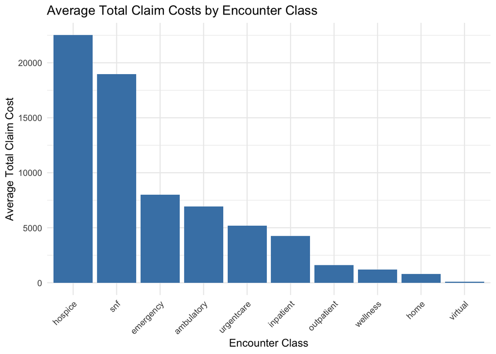

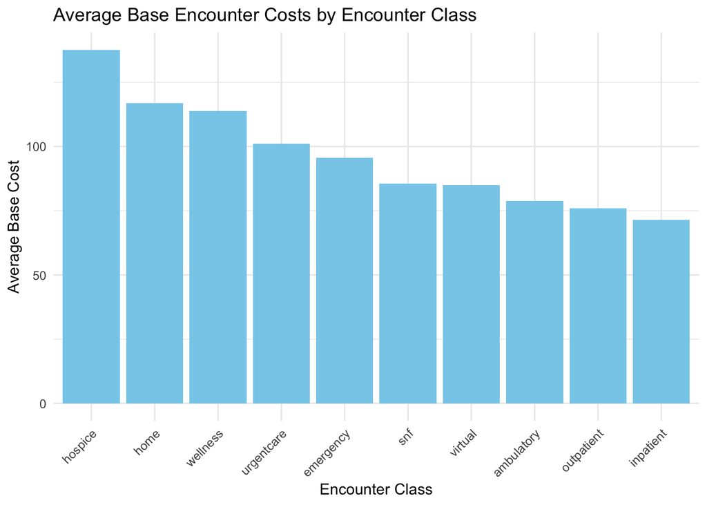

```
    Pearson's product-moment correlation

data:  encounters$base_encounter_cost and encounters$total_claim_cost
t = 1.6774, df = 5225, p-value = 0.09352
alternative hypothesis: true correlation is not equal to 0
95 percent confidence interval:
 -0.003913446  0.050278710
sample estimates:
       cor
0.02319967
```

```
Call:
lm(formula = total_claim_cost ~ base_encounter_cost + encounterclass,
    data = encounters)

Residuals:
   Min     1Q Median     3Q    Max
-22509  -4410   -310    371 515368

Coefficients:
                           Estimate Std. Error t value Pr(>|t|)
(Intercept)               -2855.644    800.807  -3.566 0.000366 ***
base_encounter_cost         124.227      9.586  12.959  < 2e-16 ***
encounterclassemergency   -1034.924    795.993  -1.300 0.193601
encounterclasshome       -10892.299   2680.433  -4.064 4.90e-05 ***
encounterclasshospice      8282.134   3917.299   2.114 0.034542 *
encounterclassinpatient   -1766.500    959.171  -1.842 0.065576 .
encounterclassoutpatient  -4995.320    392.555 -12.725  < 2e-16 ***
encounterclasssnf         11218.818   2851.131   3.935 8.43e-05 ***
encounterclassurgentcare  -4528.917    706.151  -6.414 1.55e-10 ***
encounterclassvirtual     -7618.618   4584.244  -1.662 0.096590 .
encounterclasswellness   -10077.247    489.693 -20.579  < 2e-16 ***
---
Signif. codes:  0 '***' 0.001 '**' 0.01 '*' 0.05 '.' 0.1 ' ' 1

Residual standard error: 10230 on 5216 degrees of freedom
Multiple R-squared:  0.09898,   Adjusted R-squared:  0.09725
F-statistic:  57.3 on 10 and 5216 DF,  p-value: < 2.2e-16
```

##### ANOVA Statistical Testing

```
Call:
lm(formula = total_claim_cost ~ base_encounter_cost + encounterclass,
    data = encounters)

Residuals:
   Min     1Q Median     3Q    Max
-22509  -4410   -310    371 515368

Coefficients:
                           Estimate Std. Error t value Pr(>|t|)
(Intercept)               -2855.644    800.807  -3.566 0.000366 ***
base_encounter_cost         124.227      9.586  12.959  < 2e-16 ***
encounterclassemergency   -1034.924    795.993  -1.300 0.193601
encounterclasshome       -10892.299   2680.433  -4.064 4.90e-05 ***
encounterclasshospice      8282.134   3917.299   2.114 0.034542 *
encounterclassinpatient   -1766.500    959.171  -1.842 0.065576 .
encounterclassoutpatient  -4995.320    392.555 -12.725  < 2e-16 ***
encounterclasssnf         11218.818   2851.131   3.935 8.43e-05 ***
encounterclassurgentcare  -4528.917    706.151  -6.414 1.55e-10 ***
encounterclassvirtual     -7618.618   4584.244  -1.662 0.096590 .
encounterclasswellness   -10077.247    489.693 -20.579  < 2e-16 ***
---
Signif. codes:  0 '***' 0.001 '**' 0.01 '*' 0.05 '.' 0.1 ' ' 1

Residual standard error: 10230 on 5216 degrees of freedom
Multiple R-squared:  0.09898,   Adjusted R-squared:  0.09725
F-statistic:  57.3 on 10 and 5216 DF,  p-value: < 2.2e-16
```

```
Analysis of Variance Table

Response: total_claim_cost
                      Df     Sum Sq    Mean Sq F value Pr(>F)
base_encounter_cost    1 3.2624e+08  326241796  3.1158 0.0776 .
encounterclass         9 5.9671e+10 6630115781 63.3212 <2e-16 ***
Residuals           5216 5.4615e+11  104706042
---
Signif. codes:  0 '***' 0.001 '**' 0.01 '*' 0.05 '.' 0.1 ' ' 1
```

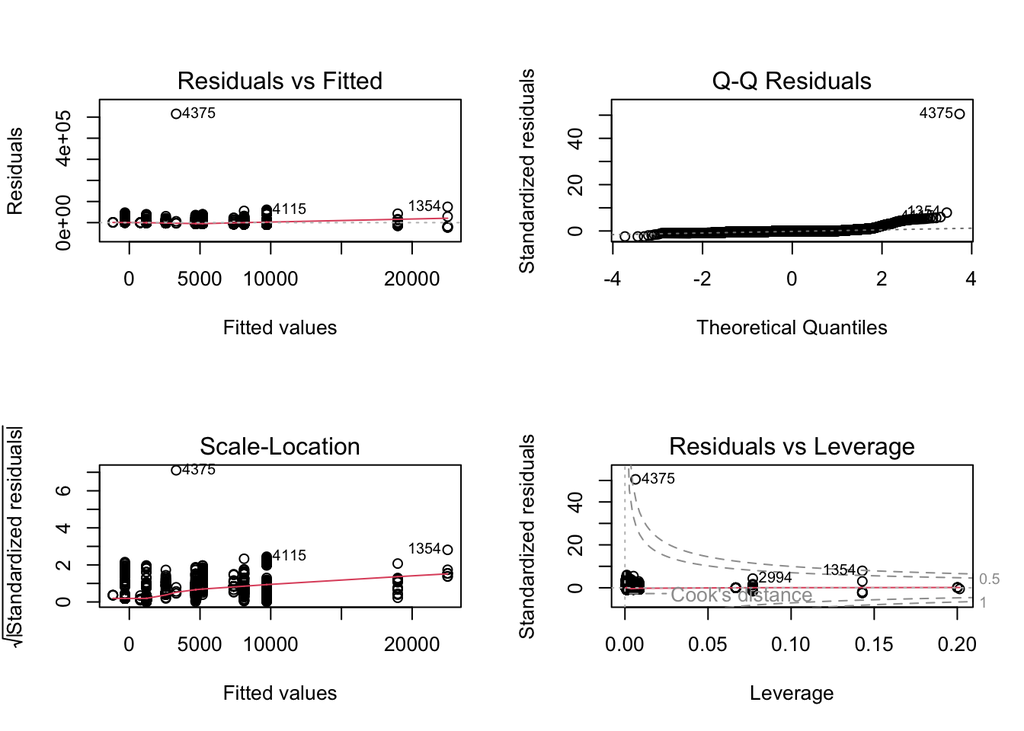

#### 2.2 Distribution per Person & per Encounter

```
# A tibble: 10 × 3
   encounterclass Average_Base_Cost_Per_Encounter Average_Total_Cost_Per_Encou…¹
   <chr>                                    <dbl>                          <dbl>
 1 hospice                                  138.                          22509.
 2 snf                                       85.5                         18981.
 3 emergency                                 95.7                          7993.
 4 ambulatory                                78.8                          6934.
 5 urgentcare                               101.                           5183.
 6 inpatient                                 71.4                          4247.
 7 outpatient                                76.0                          1595.
 8 wellness                                 114.                           1204.
 9 home                                     117.                            782.
10 virtual                                   85                              85
# ℹ abbreviated name: ¹Average_Total_Cost_Per_Encounter
```

```
# A tibble: 492 × 4
   patients_id                   encounterclass Total_Base_Cost Total_Claim_Cost
   <chr>                         <chr>                    <dbl>            <dbl>
 1 0038e191-9bca-5172-8bbd-e029… ambulatory               668.            32357.
 2 0038e191-9bca-5172-8bbd-e029… outpatient              3804.            77365.
 3 0038e191-9bca-5172-8bbd-e029… wellness                1252.            13308.
 4 02bdcf90-32f9-f93f-79d8-5a19… ambulatory               364.              930.
 5 02bdcf90-32f9-f93f-79d8-5a19… emergency                 96.6           12949.
 6 02bdcf90-32f9-f93f-79d8-5a19… outpatient               202.              474.
 7 02bdcf90-32f9-f93f-79d8-5a19… wellness                 797.             7114
 8 042ac34c-a1b1-a5ca-668e-0e2d… ambulatory               769.             5070.
 9 042ac34c-a1b1-a5ca-668e-0e2d… emergency                193.              193.
10 042ac34c-a1b1-a5ca-668e-0e2d… inpatient                 58.0               0
# ℹ 482 more rows
```

```
# A tibble: 10 × 3
   encounterclass Average_Base_Cost_Per_Person Average_Total_Cost_Per_Person
   <chr>                                 <dbl>                         <dbl>
 1 ambulatory                           1073.                         94410.
 2 urgentcare                            770.                         39452.
 3 hospice                               193.                         31512.
 4 emergency                             252.                         21062.
 5 wellness                             1910.                         20207.
 6 outpatient                            915.                         19198.
 7 snf                                    85.5                        18981.
 8 inpatient                             260.                         15490.
 9 home                                 1754.                         11724.
10 virtual                                85                             85
```

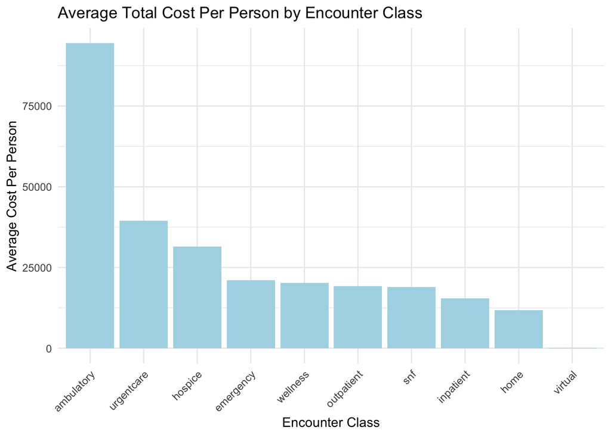

#### 2.3 Predictive Modeling – Estimate total claim costs

```
Call:
lm(formula = total_claim_cost ~ base_encounter_cost + encounterclass,
    data = encounters)

Residuals:
   Min     1Q Median     3Q    Max
-22509  -4410   -310    371 515368

Coefficients:
                           Estimate Std. Error t value Pr(>|t|)
(Intercept)               -2855.644    800.807  -3.566 0.000366 ***
base_encounter_cost         124.227      9.586  12.959  < 2e-16 ***
encounterclassemergency   -1034.924    795.993  -1.300 0.193601
encounterclasshome       -10892.299   2680.433  -4.064 4.90e-05 ***
encounterclasshospice      8282.134   3917.299   2.114 0.034542 *
encounterclassinpatient   -1766.500    959.171  -1.842 0.065576 .
encounterclassoutpatient  -4995.320    392.555 -12.725  < 2e-16 ***
encounterclasssnf         11218.818   2851.131   3.935 8.43e-05 ***
encounterclassurgentcare  -4528.917    706.151  -6.414 1.55e-10 ***
encounterclassvirtual     -7618.618   4584.244  -1.662 0.096590 .
encounterclasswellness   -10077.247    489.693 -20.579  < 2e-16 ***
---
Signif. codes:  0 '***' 0.001 '**' 0.01 '*' 0.05 '.' 0.1 ' ' 1

Residual standard error: 10230 on 5216 degrees of freedom
Multiple R-squared:  0.09898,   Adjusted R-squared:  0.09725
F-statistic:  57.3 on 10 and 5216 DF,  p-value: < 2.2e-16
```

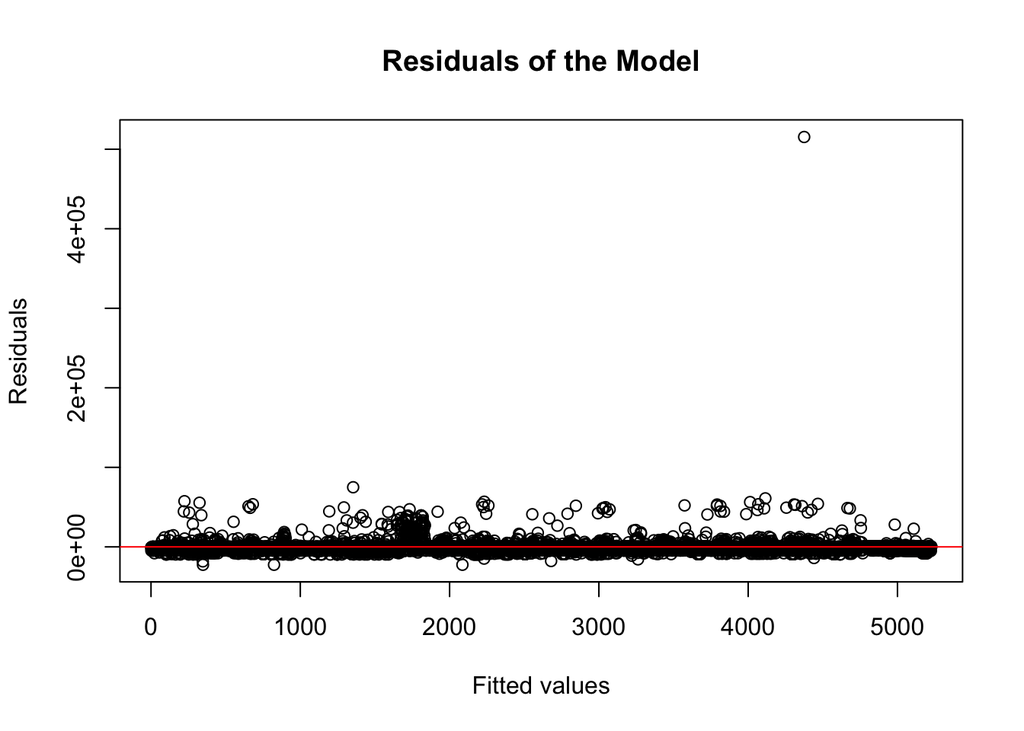

#### Summary

```
    Pearson's product-moment correlation

data:  encounters$base_encounter_cost and encounters$total_claim_cost
t = 1.6774, df = 5225, p-value = 0.09352
alternative hypothesis: true correlation is not equal to 0
95 percent confidence interval:
 -0.003913446  0.050278710
sample estimates:
       cor
0.02319967
```

```
Analysis of Variance Table

Response: total_claim_cost
                      Df     Sum Sq    Mean Sq F value Pr(>F)
base_encounter_cost    1 3.2624e+08  326241796  3.1158 0.0776 .
encounterclass         9 5.9671e+10 6630115781 63.3212 <2e-16 ***
Residuals           5216 5.4615e+11  104706042
---
Signif. codes:  0 '***' 0.001 '**' 0.01 '*' 0.05 '.' 0.1 ' ' 1
```

```
Call:
lm(formula = total_claim_cost ~ base_encounter_cost + encounterclass,
    data = encounters)

Residuals:
   Min     1Q Median     3Q    Max
-22509  -4410   -310    371 515368

Coefficients:
                           Estimate Std. Error t value Pr(>|t|)
(Intercept)               -2855.644    800.807  -3.566 0.000366 ***
base_encounter_cost         124.227      9.586  12.959  < 2e-16 ***
encounterclassemergency   -1034.924    795.993  -1.300 0.193601
encounterclasshome       -10892.299   2680.433  -4.064 4.90e-05 ***
encounterclasshospice      8282.134   3917.299   2.114 0.034542 *
encounterclassinpatient   -1766.500    959.171  -1.842 0.065576 .
encounterclassoutpatient  -4995.320    392.555 -12.725  < 2e-16 ***
encounterclasssnf         11218.818   2851.131   3.935 8.43e-05 ***
encounterclassurgentcare  -4528.917    706.151  -6.414 1.55e-10 ***
encounterclassvirtual     -7618.618   4584.244  -1.662 0.096590 .
encounterclasswellness   -10077.247    489.693 -20.579  < 2e-16 ***
---
Signif. codes:  0 '***' 0.001 '**' 0.01 '*' 0.05 '.' 0.1 ' ' 1

Residual standard error: 10230 on 5216 degrees of freedom
Multiple R-squared:  0.09898,   Adjusted R-squared:  0.09725
F-statistic:  57.3 on 10 and 5216 DF,  p-value: < 2.2e-16
```

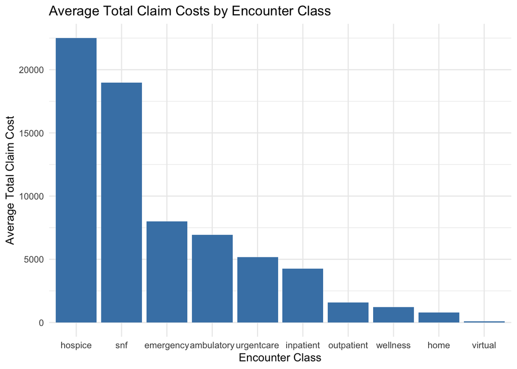

## RQ3: Health Outcomes (Xinyu Zhang 100%)

### Introduction

Understanding the impact of out-of-pocket expenses on healthcare-seeking behavior is crucial for designing patient-centric insurance policies. This analysis begins with an overarching view of all patients under BlueStar’s plans, focusing on how variations in out-of-pocket expense ratios influence key healthcare behaviors such as revisit rates and acute care utilization. By identifying broad trends across the entire patient population, we aim to uncover initial insights that will inform more targeted demographic and socioeconomic analyses.

*RQ3：How do out-of-pocket expenses, categorized by factors like age, gender, and income, influence how patients seek healthcare under BlueStar’s plans?*  
The analysis was conducted in two stages:

1. **Overall Analysis**:  
   Revisit Rate and Acute Care Rate: Explored broad trends across all patients, comparing healthcare utilization patterns for those with above-average and below-average OOP ratios. This provided initial insights into the relationship between financial burden and healthcare behavior.  
   Encounter Class: Analyzed how OOP ratios vary across different types of healthcare services to identify utilization trends.  
   County-Level OOP Patterns: Examined geographic disparities in average OOP ratios and their impact on revisit and acute care rates to uncover location-specific affordability issues.
2. **In-Depth Analysis**:  
   County-Level Analysis: Conducted detailed assessments of revisit and acute care rates within high and low OOP counties to understand localized impacts of financial burden on healthcare behavior.  
   Demographic Analysis (Age, Gender, Income): Investigated how OOP ratios affect healthcare utilization within specific demographic groups:
- Age: Analyzed differences in revisit and acute care rates across age brackets to uncover age-specific sensitivities to OOP costs.
- Gender: Examined gender-based disparities to identify differences in financial sensitivity and healthcare-seeking behavior.
- Income: Explored how income levels moderate the relationship between OOP costs and healthcare utilization, highlighting the varying impacts on High, Low, Lower-Middle, and Middle income groups.

Through these analyses, the study aims to identify actionable insights and trends that can inform policy decisions, improve healthcare affordability, and promote equitable access to care under BlueStar’s insurance plans.

#### 3.1 Overall Analysis

##### 3.1.1 Overall Revisit Rate and Acute Care Rate

This boxplot compares **revisit rates** between patients with **above-average** and **below-average out-of-pocket (OOP) ratios**:

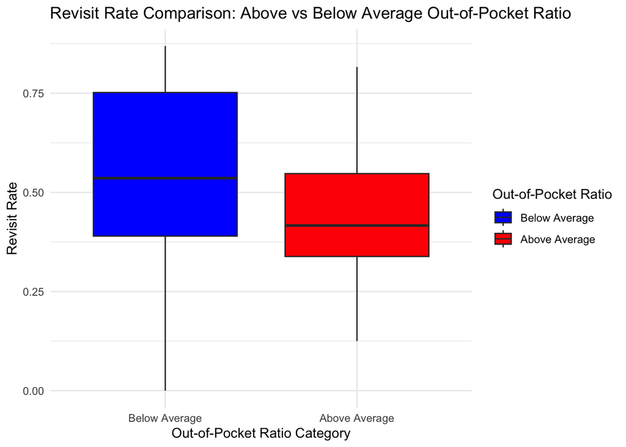

**Below-Average OOP Ratio** (Blue Box):  
- Patients in this group generally have higher revisit rates, with the median revisit rate exceeding 0.5.  
- The wide range indicates variability in healthcare utilization, but most patients revisit healthcare services more frequently than those in the above-average group.  
- This suggests that lower OOP expenses encourage more frequent follow-up visits.

**Above-Average OOP Ratio** (Red Box):  
- Patients with higher OOP ratios show lower revisit rates, with the median value below 0.5.  
- The narrower range indicates less variability compared to the below-average group, but consistently lower revisit rates imply financial barriers discouraging patients from seeking timely follow-up care.

**Insights**:  
Patients with above-average out-of-pocket ratios appear to have lower revisit rates compared to those with below-average out-of-pocket ratios. This could indicate:  
- Higher OOP ratios appear to discourage patients from revisiting healthcare providers, potentially leading to delayed care or untreated conditions.  
- Policies reducing OOP expenses could incentivize timely follow-up care, improving health outcomes.

This boxplot compares **acute care rates** between patients with **above-average** and **below-average out-of-pocket (OOP) ratios**:

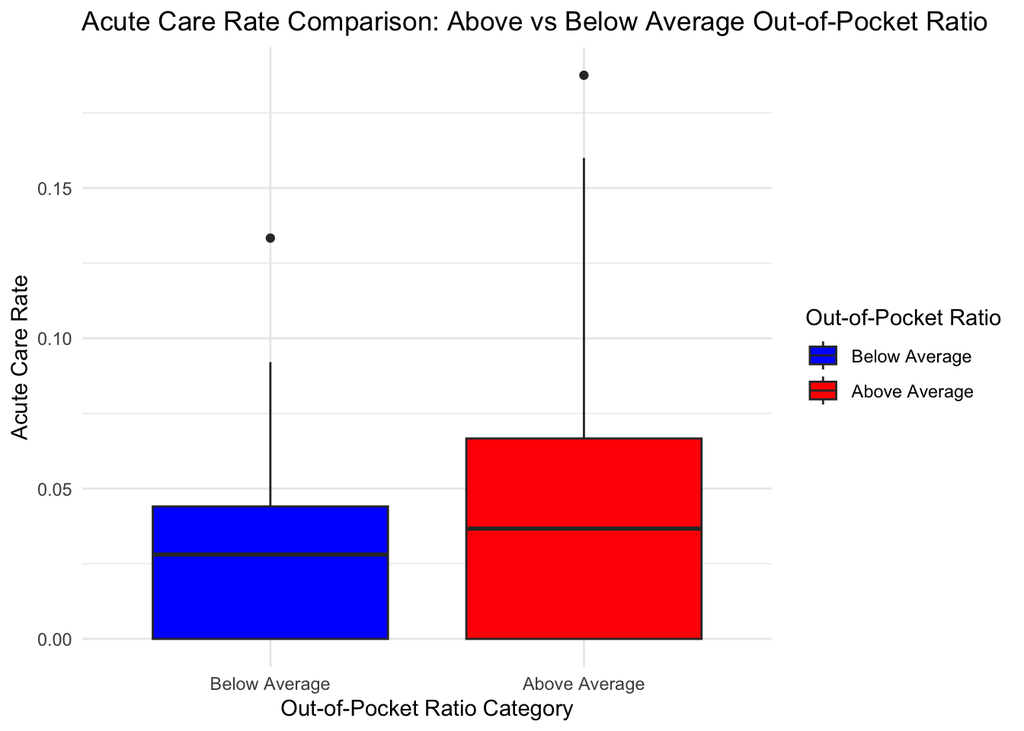

**Below-Average OOP Ratio** (Blue Box):  
- Patients in this group have lower acute care rates, with the median acute care rate near 0.025.  
- The distribution is relatively tight, indicating less variability in acute care utilization for patients with lower financial burdens.

**Above-Average OOP Ratio** (Red Box):  
- Patients with higher OOP ratios have higher acute care rates, with the median closer to 0.05.  
- The distribution is wider, and there are noticeable outliers, indicating greater variability in acute care utilization.  
- This suggests that higher OOP expenses may result in delayed or avoided regular care, increasing the likelihood of acute care visits.

**Insights**:  
Higher acute care rates in the above-average group suggest that:  
- Higher OOP ratios are associated with increased acute care rates, supporting the idea that financial barriers discourage timely or preventive healthcare, leading to more emergency care.  
- Policies aimed at reducing OOP expenses could help prevent acute care situations by enabling patients to seek earlier, less critical care.

##### 3.1.2 Encounter Class

This bar chart shows the **average out-of-pocket (OOP) ratio** for different types of healthcare encounters (encounter classes).

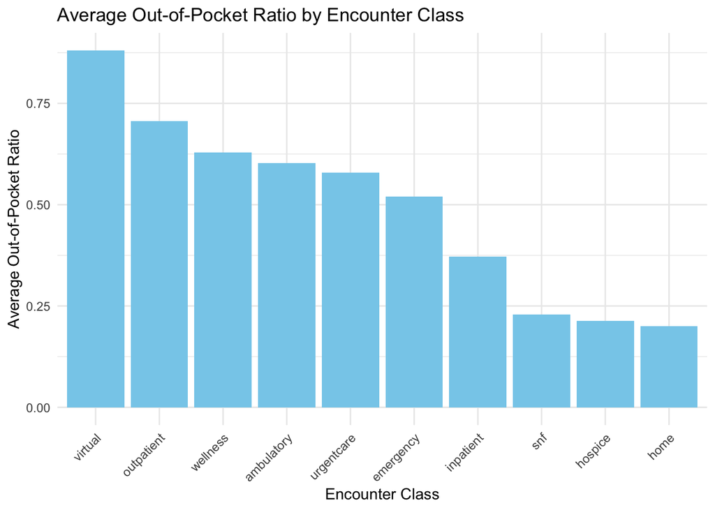

**Virtual Visits**:  
- Virtual encounters have the highest average OOP ratio, indicating that patients are paying a larger share of the costs for these services compared to other encounter types.

**Outpatient and Wellness Visits**:  
- These encounter classes also show relatively high OOP ratios, suggesting that preventive and routine healthcare services may impose significant financial burdens on patients.

**Ambulatory, Urgent Care, and Emergency Services**:  
- These encounter types fall in the mid-range for OOP ratios. Emergency services, while critical, still show a substantial financial burden on patients.

**Inpatient and Long-Term Care (SNF, Hospice, Home)**:  
- Inpatient, skilled nursing facilities (SNF), hospice, and home care services have lower OOP ratios. These services may receive more extensive coverage, reducing the patient’s financial responsibility.

**Insights**:  
- The high OOP ratios for virtual, outpatient, and wellness services suggest barriers to accessing these types of care, which are often preventive or non-urgent  
- This chart highlights potential areas for policy improvements, such as reducing OOP costs for virtual and outpatient care, to encourage preventive healthcare and reduce downstream emergency or acute care needs.

##### 3.1.3 County

This bar chart shows the **average out-of-pocket (OOP) ratio** for healthcare expenses by county, ranked from highest to lowest.

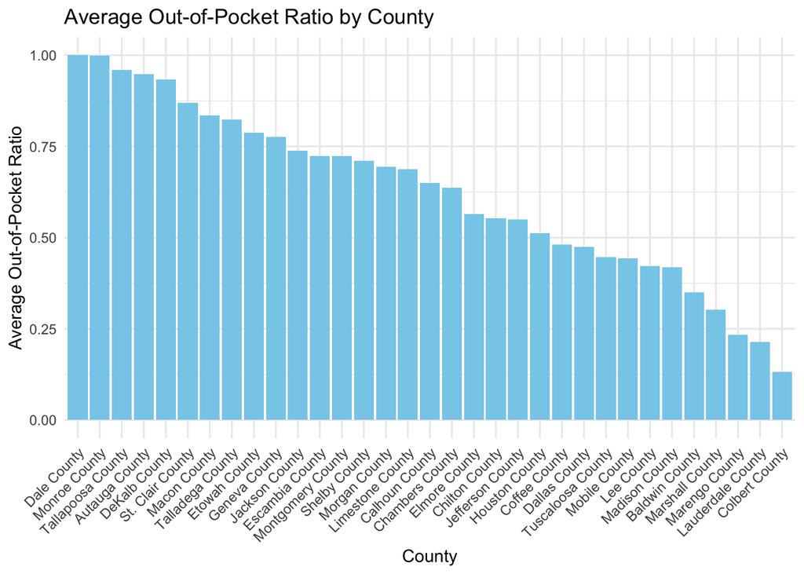

**Counties with High OOP Ratios**:  
- Dale County, Monroe County, and Tallapoosa County have the highest average OOP ratios, nearing 1. This indicates that patients in these counties bear a significant share of their healthcare costs, suggesting high financial burdens for medical services.  
- These counties may have limited insurance coverage, higher service costs.

**Counties with Low OOP Ratios**:  
- Colbert County, Lauderdale County, and Marengo County show the lowest OOP ratios. Patients in these counties pay a smaller proportion of their healthcare costs, indicating more affordable access to medical services or better insurance coverage.

**Geographic Disparities**:  
- The chart highlights significant geographic differences in the financial burden faced by patients across counties.  
- Higher OOP ratios may discourage patients from seeking timely healthcare, potentially leading to worse health outcomes in high-burden counties.

**Insights**:  
- High-OOP counties could benefit from targeted interventions, such as subsidies or expanded insurance coverage, to reduce financial barriers to healthcare access.

#### 3.2 Deep Dive

##### 3.2.1 County-Level Analysis

This boxplot compares the **average revisit rate (per patient)** between counties with **high out-of-pocket (High OOP)** and **low out-of-pocket (Low OOP)** ratios.

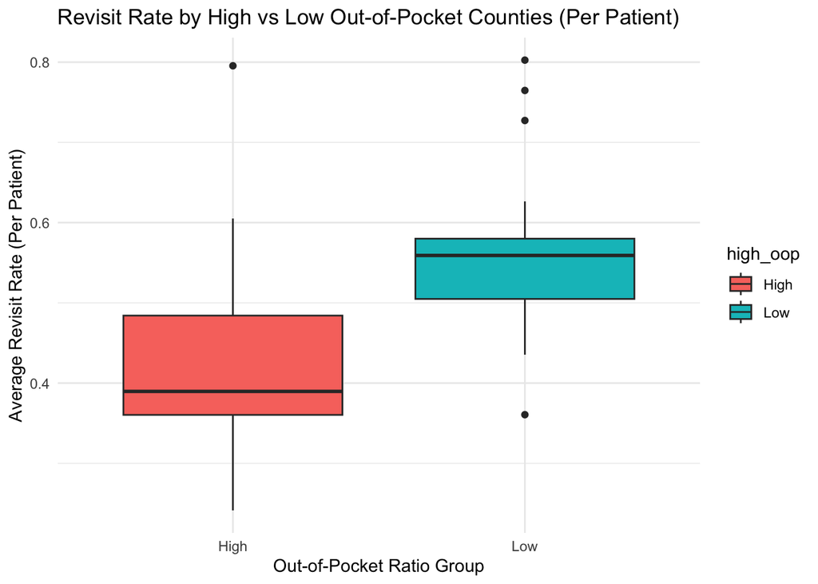

**High OOP Counties (Red Box)**:  
- The median revisit rate is lower compared to low OOP counties, suggesting that patients in high OOP counties are less likely to revisit healthcare providers.  
- The distribution is wider, with a larger interquartile range. This indicates greater variability in healthcare-seeking behavior across these counties.  
- The lower revisit rate may reflect financial barriers discouraging follow-up visits for patients with higher OOP expenses.

**Low OOP Counties (Blue Box)**:  
- The median revisit rate is higher than in high OOP counties, indicating that patients in low OOP counties are more likely to revisit healthcare providers.  
- The distribution is narrower, indicating less variability in revisit rates among these counties.  
- The higher revisit rate could be due to lower financial barriers, allowing patients to access follow-up care more easily.

**Insights**:  
- The results suggest that higher out-of-pocket expenses discourage follow-up visits, potentially delaying treatment or ongoing care management in high OOP counties.  
- In contrast, patients in low OOP counties seem to face fewer financial obstacles, enabling them to seek timely and consistent care.

This boxplot compares the **average acute care rate (per patient)** between counties with **high** and **low out-of-pocket (OOP) ratios**.

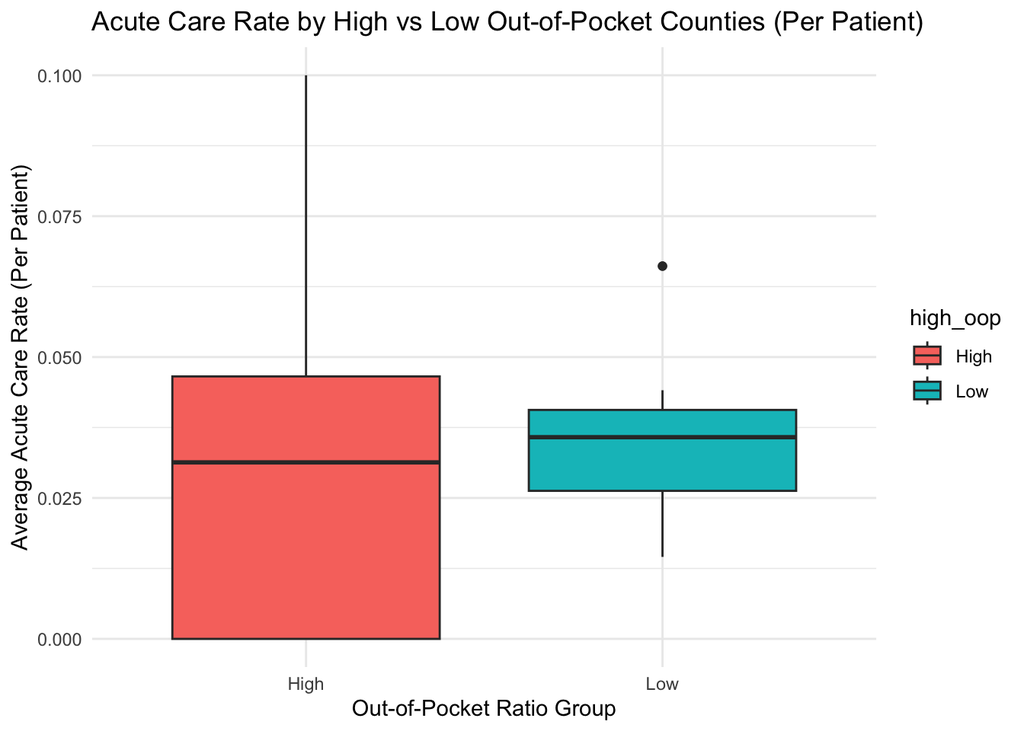

**High OOP Counties** (Red Box):  
- The median acute care rate is lower for high OOP counties compared to low OOP counties, indicating that there might be imbalance healthcare resource distribution.High OOP counties might have fewer healthcare facilities or resources, limiting access to acute care services and resulting in lower utilization.  
- Low OOP counties may have better access to healthcare infrastructure, encouraging higher acute care utilization.  
- The distribution shows greater variability, with some counties exhibiting significantly higher acute care rates.

**Low OOP Counties** (Blue Box):  
- The distribution is more compact, suggesting that patients in these counties may have better access to preventive or routine care, reducing the reliance on acute care services.  
- The smaller range indicates less variability in acute care utilization across these counties.

**Insights**:  
- The method used to classify counties as high or low OOP could include edge cases, where some high OOP counties inherently have lower acute care utilization due to unique local factors.

This is the result of a linear regression analysis where the **average revisit rate** is modeled as a function of the **average out-of-pocket (OOP) ratio** across counties.

```
Call:
lm(formula = avg_revisit_rate ~ avg_out_of_pocket_ratio, data = county_analysis)

Residuals:
     Min       1Q   Median       3Q      Max
-0.20567 -0.06858 -0.01967  0.05594  0.38333

Coefficients:
                        Estimate Std. Error t value Pr(>|t|)
(Intercept)              0.68622    0.06507  10.545 8.89e-12 ***
avg_out_of_pocket_ratio -0.28648    0.09605  -2.983  0.00553 **
---
Signif. codes:  0 '***' 0.001 '**' 0.01 '*' 0.05 '.' 0.1 ' ' 1

Residual standard error: 0.1242 on 31 degrees of freedom
Multiple R-squared:  0.223, Adjusted R-squared:  0.1979
F-statistic: 8.896 on 1 and 31 DF,  p-value: 0.005528
```

**Statistical Significance**:  
- The **p-value** for the slope term is less than 0.01, indicating a statistically significant relationship between the OOP ratio and revisit rates.

**Insights**:  
- Higher OOP ratios discourage patients from revisiting healthcare providers, as evidenced by the negative slope. This aligns with the hypothesis that financial burdens can act as a barrier to follow-up care.

This is the result of a linear regression analysis where the **average acute care rate** is modeled as a function of the **average out-of-pocket (OOP) ratio** across counties.

```
Call:
lm(formula = avg_acute_care_rate ~ avg_out_of_pocket_ratio, data = county_analysis)

Residuals:
      Min        1Q    Median        3Q       Max
-0.034121 -0.012424 -0.001241  0.007238  0.066785

Coefficients:
                         Estimate Std. Error t value Pr(>|t|)
(Intercept)              0.037930   0.012312   3.081  0.00431 **
avg_out_of_pocket_ratio -0.004914   0.018174  -0.270  0.78865
---
Signif. codes:  0 '***' 0.001 '**' 0.01 '*' 0.05 '.' 0.1 ' ' 1

Residual standard error: 0.02351 on 31 degrees of freedom
Multiple R-squared:  0.002353,  Adjusted R-squared:  -0.02983
F-statistic: 0.07311 on 1 and 31 DF,  p-value: 0.7887
```

The regression results suggest that the **average out-of-pocket (OOP) ratio** does not have a **direct, linear relationship** with the **acute care rate**. However, this does not rule out the possibility of a more complex or indirect relationship.  
- Higher OOP ratios might discourage patients from seeking preventive or routine care, which could indirectly increase the need for acute care. This delayed effect might not be captured by a simple linear regression.

##### 3.2.2 Age Analysis

This bar chart shows the **average revisit rate** across different age groups, split by out-of-pocket (OOP) ratio categories (above or below average).

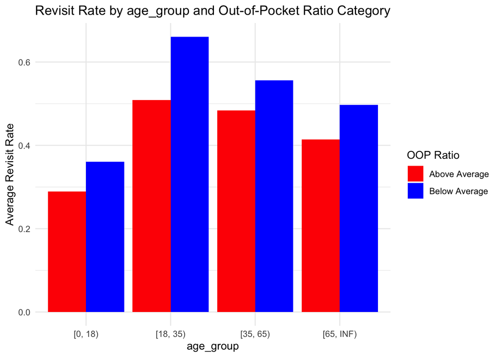

**Age Group [0, 18]**:  
- The revisit rate is slightly lower for patients with above-average OOP ratios (red bar) compared to those with below-average OOP ratios (blue bar).  
- This suggests that higher OOP costs may deter younger patients or their families from seeking follow-up care.

**Age Group [18, 35]**:  
- Patients in this group show a higher revisit rate, especially for those with below-average OOP ratios.  
- The gap between above-average and below-average OOP ratios is the largest in this group, indicating that young adults are more sensitive to financial barriers when deciding whether to seek follow-up care.

**Age Group [35, 65]**:  
- The revisit rates are generally high for this group, with below-average OOP ratios again resulting in higher revisit rates compared to above-average OOP ratios.  
- The gap is smaller compared to the [18, 35] group but still noticeable, showing moderate sensitivity to OOP costs.

**Age Group [65, INF]**:  
- In this older age group, the revisit rates is slightly lower for patients with above-average OOP ratios compared to those with below-average OOP ratios.

**Insights**:  
Higher OOP ratios consistently reduce revisit rates across all age groups, but the effect varies:  
- **Younger groups (18–35)** are more sensitive to financial barriers.

This bar chart shows the **average acute care rate** across different age groups, split by out-of-pocket (OOP) ratio categories (above or below average).

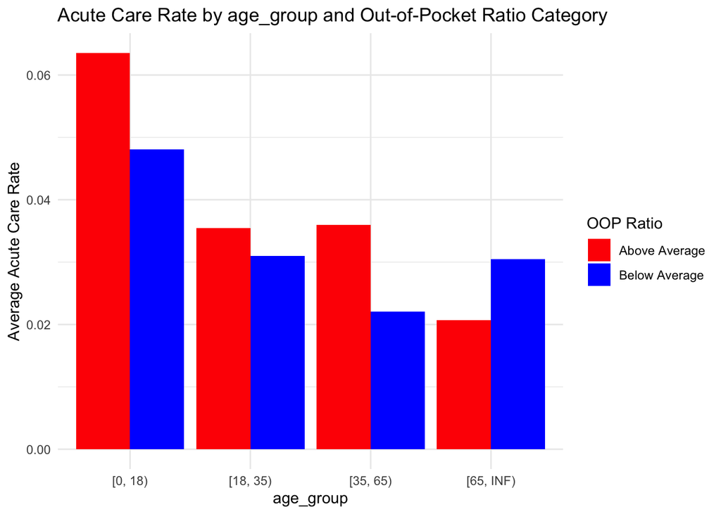

**Age Group [0, 18]**:  
- The acute care rate is significantly higher for patients in the above-average OOP ratio category compared to the below-average group.  
- This suggests that higher OOP costs may lead to delayed or avoided routine care for children, resulting in more acute care visits.  
**Age Group [18, 35]**:  
- The acute care rates are relatively similar between the two OOP categories, with a slight advantage for below-average OOP patients.  
- Young adults may be less dependent on acute care services overall, showing less sensitivity to OOP costs in this age range.  
**Age Group [35, 65]**:  
- Acute care rates are higher for the above-average OOP group than the below-average group, indicating that adults in this age group may be affected by OOP costs, potentially leading to higher reliance on acute care when preventive or follow-up care is avoided.  
**Age Group [65, INF]**:  
- Unlike other groups, the below-average OOP category shows slightly higher acute care rates compared to the above-average group.  
- Older adults in the above-average OOP group may avoid or delay seeking acute care due to the high out-of-pocket costs, even when they experience serious health conditions. This avoidance doesn’t necessarily mean they are healthier but could reflect a financial trade-off that worsens their underlying health over time.  
- High OOP costs might push elderly patients to rely on self-treatment, over-the-counter medication, or informal caregiving instead of professional acute care. These alternatives are often less effective and may result in worsening conditions.  
**Insights**:  
The impact of OOP costs on acute care utilization is age-dependent, with children and middle-aged adults showing the greatest vulnerability, while older adults face unique challenges from cost-related care avoidance. Tailored interventions for each age group are essential to optimize healthcare access and outcomes.

##### 3.2.3 Gender Analysis

This bar chart compares the **average revisit rate** by **gender** and **out-of-pocket (OOP) ratio category** (above average in red and below average in blue).

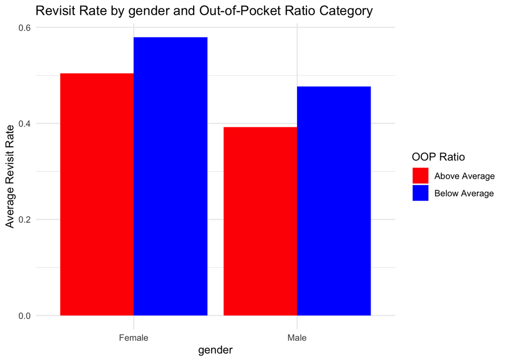

**Females**:  
- Females in the **below-average OOP group** have significantly higher revisit rates compared to those in the **above-average OOP group**.  
- This suggests that higher OOP costs act as a barrier for women, discouraging follow-up visits when costs are high.  
- Women in the below-average OOP group appear to utilize healthcare more consistently, likely due to reduced financial constraints.  
**Males**:  
- Similar to females, males in the **below-average OOP group** have higher revisit rates than those in the **above-average OOP group**.  
**Gender Comparison**:  
- Overall, women in both OOP categories tend to have higher revisit rates than men, indicating that women may generally seek follow-up care more often, potentially due to greater healthcare needs or better health-seeking behavior.  
**Insights**:  
This chart highlights significant gender differences in healthcare utilization. Men tend to have lower overall revisit rates. Tailored policies aimed at reducing OOP costs and promoting follow-up care for men can help address these disparities and improve health outcomes.

This bar chart compares the **average acute care rate** by **gender** and **out-of-pocket (OOP) ratio category** (above average in red and below average in blue).

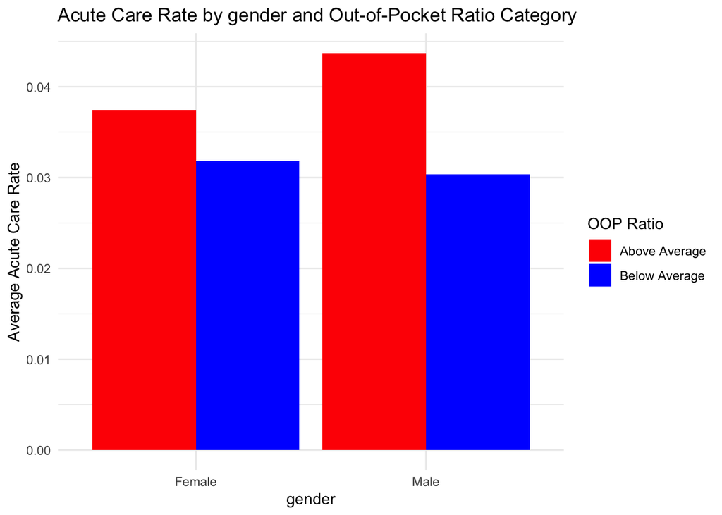

##### 3.2.4 Income Analysis

This bar chart compares the **average revisit rate** across different **income categories** (High, Low, Lower-Middle, and Middle), split by **out-of-pocket (OOP) ratio categories**.

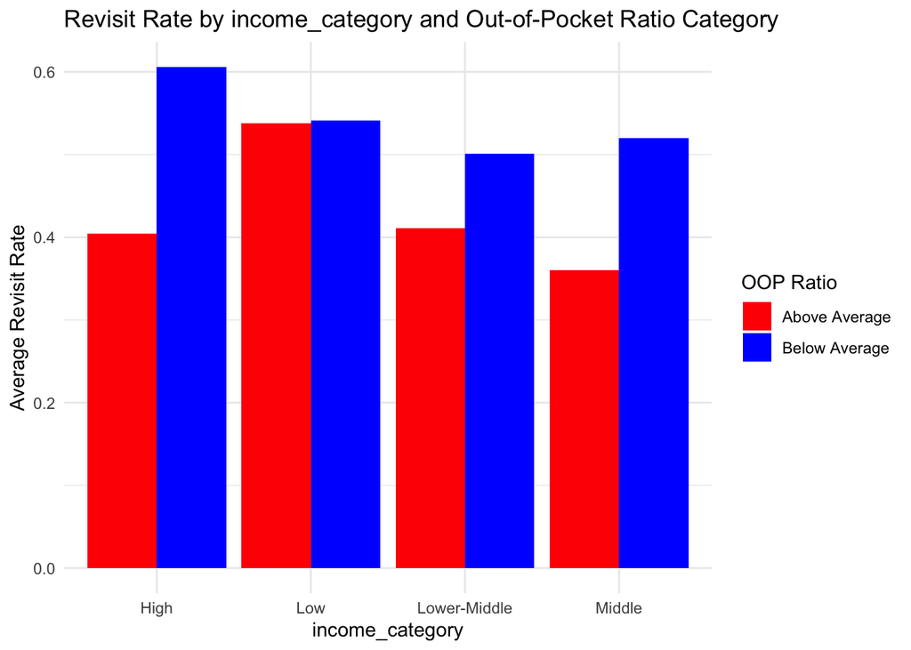

**High-Income Category**:  
- Revisit rates are **higher for the below-average OOP group** than the above-average OOP group.  
- Even in high-income populations, financial barriers (higher OOP ratios) appear to discourage follow-up care.  
- High-income individuals typically have a stronger health awareness and are more proactive in monitoring their health. Low deductibles lower the cost barrier for high-income individuals, and their health awareness drives them to pursue follow-up care more actively. **Low-Income Category**:  
- Revisit rates are **slightly higher for the below-average OOP group** than the above-average OOP group.  
- Low-income populations often face higher rates of chronic illnesses, such as diabetes, hypertension, or asthma, which require frequent follow-ups to manage. These individuals may also experience poorer baseline health, necessitating more frequent visits to maintain stability.  
**Lower-Middle Income Category**:  
- The revisit rates are again higher for the below-average OOP group, with a moderate gap between the two OOP categories.  
**Middle-Income Category**:  
- This category shows the **large gap** between the below-average and above-average OOP groups, with the below-average group having much higher revisit rates.  
- This suggests that middle-income individuals are particularly vulnerable to higher OOP costs, possibly because they may not qualify for subsidies but still face significant financial constraints.  
**Insights**: Across all income groups, individuals in the below-average OOP category have higher revisit rates, indicating that financial barriers deter follow-up care. High-income and middle-income groups are the most sensitive to OOP costs, with significant drops in revisit rates for those in the above-average OOP group.

This bar chart compares the **average acute care rate** across different **income categories** (High, Low, Lower-Middle, and Middle), split by **out-of-pocket (OOP) ratio categories**.

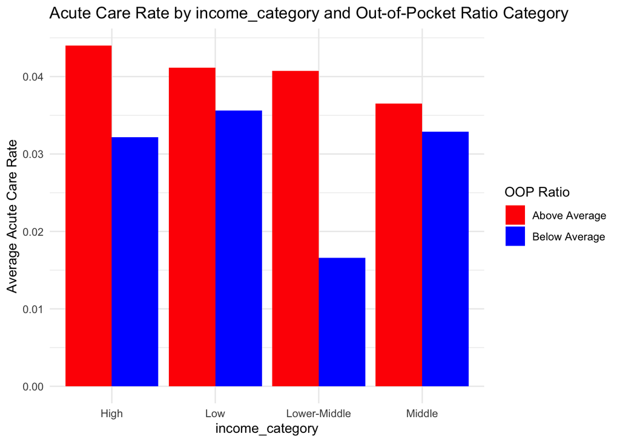

**High-Income Category**:  
- Acute care rates are **higher for the above-average OOP group** compared to the below-average group.  
- High-income individuals typically have a stronger sense of health awareness and are more likely to utilize healthcare resources for prevention and treatment. When deductibles are lower, they are more inclined to perceive minor or moderate issues as requiring emergency care, leading to an increased utilization of emergency services. They may also prefer emergency services to save time. However, when deductibles are higher, they may opt for other, more cost-effective healthcare options.  
**Low-Income Category**:  
- Acute care rates are also **higher for the above-average OOP group**, but the gap between the two groups is small. This suggests that financial barriers impact low-income individuals’ healthcare decisions, but acute care usage may be more driven by necessity due to poor baseline health or limited access to preventive care.  
**Lower-Middle Income Category**:  
- The **largest gap** in acute care rates is observed in this category, with significantly higher rates for the above-average OOP group.  
- This indicates that lower-middle-income individuals are particularly vulnerable to higher OOP costs, as they may not qualify for financial subsidies yet still face financial strain.  
**Middle-Income Category**:  
- Acute care rates are consistently higher for the above-average OOP group, showing a moderate gap compared to the below-average group.  
- Middle-income individuals may be financially constrained, causing delays in preventive or follow-up care and leading to greater acute care needs.  
**Insights**:  
In all income categories, individuals with higher OOP ratios rely more on acute care. This trend indicates that financial barriers discourage timely healthcare access, increasing the likelihood of emergencies.

#### Recommendation

To address RQ3, we propose the following recommendations to mitigate the impact of financial barriers on healthcare access and utilization:

**1. Targeted Copayment Reductions**  
The analysis revealed that higher OOP expenses discourage follow-up visits, especially in high-OOP counties and among middle-income and younger populations. To address this:  
- **Lower copayments for preventive and follow-up care** in high-OOP regions to remove financial barriers. This is particularly effective for younger patients ([0–35]) and middle-income groups, who are more sensitive to cost.  
- **Zero-copay options for critical services** such as chronic disease management or pediatric checkups, ensuring affordability for at-risk populations.  
**2. Flexible Payment Plans**  
The findings show that financial stress leads to delayed or avoided care, increasing reliance on acute care services. Introducing **flexible payment plans** can help mitigate this:  
- **Installment-based payment options** for high-cost treatments to ease the short-term financial burden on families.  
- **Income-sensitive sliding scales** for deductibles and copayments, particularly for middle-income groups who may not qualify for subsidies yet face significant financial strain.  
- **Incentivized health rewards** to encourage follow-ups, offering discounts or loyalty benefits for adherence to care plans.

**3. Educational Campaigns**  
The data suggests that awareness and health-seeking behavior vary across income, age, and gender. Educational initiatives can address disparities by:  
- **Promoting preventive care** through targeted messaging in high-OOP counties, emphasizing the long-term savings and health benefits of timely follow-ups.  
- **Engaging different demographics** with tailored content:  
- For young adults, focus on proactive health management to reduce acute care dependence.  
- For seniors, provide resources on affordable chronic disease management.  
- **Leveraging digital tools** like cost calculators and telehealth guides to simplify access to information for policyholders.

These recommendations directly address how out-of-pocket expenses influence healthcare-seeking behavior by mitigating financial barriers, enhancing access to preventive care, and tailoring solutions based on age, gender, and income. By implementing these strategies, BlueStar can improve policyholder health outcomes, reduce long-term costs, and ensure equitable access to care across all demographics.

# References

Jones, B., & Jing, A. (2011). Prevention not cure in tackling healthcare fraud. Bulletin of the World Health Organization, 89(12), 858–859. https://doi.org/10.2471/BLT.11.021211.

Shi, P., Feng, X., & Ivantsova, A. (2015). Dependent frequency–severity modeling of insurance claims. Insurance: Mathematics and Economics, 64, 417–428. https://doi.org/10.1016/j.insmatheco.2015.07.006

Van Loenen T, Faber MJ, Westert GP, Van den Berg MJ. The impact of primary care organization on avoidable hospital admissions for diabetes in 23 countries. Scand J Prim Health Care. 2016;34(1):5–12. https://doi.org/10.3109/02813432.2015.1132883.

World Bank (2018). Combating corruption. World Bank https://www.worldbank.org/en/topic/governance/brief/anti-corruption (Accessed 4 Dec 2024).